# python-api-covid-pandas

## Uso de la API del Covid-19 con Pandas

En esta práctica vamos a utilizar *Pandas*, la librería de Phyton, para trabajar sobre los datos de la Covid-19 y analizarlos.

La URL: https://api.covid19api.com/countries

### Instalción de librerías:

Para instalar la librería utilizaremos la función `!pip`. La exclamación es necesaria porque no estamos ejecutando Python, sino bash.

```python
!pip install pandas
```

### Configuración de Pandas

Para importar utilizaremos la convención *pd* como abrebiatura para llamar a la librería.

```python
import pandas as pd
```

### Crear variable

Las variables se asignan con el símbolo `=` y los escribimos entrecomillados por ser una cadena de caracteres.

```python
url = "https://api.covid19api.com/countries"
```

### Crear dataframe

La abreviatura que se emplea para los dataframe es *df*. Existe una función `read_json()` que lo que hace es leer el formato *json*. Dentro del paréntesis indicaremos el valor de lo que queremos que lea, en este caso la url.

```python
df = pd.read_json(url)
```

Para visualizar los datos llamamos al objeto. Observaremos una tabla que contiene tres columnas y una columna de control de Pandas, que identifica cada una de las entradas del dataframe.

```python
df
```

|  | Country | Slug | ISO2 |
| --- | --- | --- | --- |
| 0 | Gambia | gambia | GM |
| 1 | Paraguay | paraguay | PY |
| 2 | Trinidad and Tobago | trinidad-and-tobago | TT |
| 3 | Austria | austria | AT |
| 4 | Sao Tome and Principe | sao-tome-and-principe | ST |
| ... | ... | ... | ... |
| 243 | Cape Verde | cape-verde | CV |
| 244 | Israel | israel | IL |
| 245 | Bolivia | bolivia | BO |
| 246 | Latvia | latvia | LV |
| 247 | Papua New Guinea | papua-new-guinea | PG |

248 rows × 3 columns

### Exploración de la tabla

Para ver las primeras entradas de la tabla utilizaremos la siguiente función. Como metemos el número 6 veremos las seis primeras observaciones.

```python
df.head(6)
```

|  | Country | Slug | ISO2 |
| --- | --- | --- | --- |
| 0 | Gambia | gambia | GM |
| 1 | Paraguay | paraguay | PY |
| 2 | Trinidad and Tobago | trinidad-and-tobago | TT |
| 3 | Austria | austria | AT |
| 4 | Sao Tome and Principe | sao-tome-and-principe | ST |
| 5 | Timor-Leste | timor-leste | TL |

Para ver las 6 últimas entradas:

```python
df.tail(6)
```

|  | Country | Slug | ISO2 |
| --- | --- | --- | --- |
| 242 | Barbados | barbados | BB |
| 243 | Cape Verde | cape-verde | CV |
| 244 | Israel | israel | IL |
| 245 | Bolivia | bolivia | BO |
| 246 | Latvia | latvia | LV |
| 247 | Papua New Guinea | papua-new-guinea | PG |

Para ver las información sobre las variables que contiene el dataframe utilizamos la siguiente función:

```python
df.info()
```

```
<class 'pandas.core.frame.DataFrame'>
RangeIndex: 248 entries, 0 to 247
Data columns (total 3 columns):
 #   Column   Non-Null Count  Dtype
---  ------   --------------  -----
 0   Country  248 non-null    object
 1   Slug     248 non-null    object
 2   ISO2     248 non-null    object
dtypes: object(3)
memory usage: 5.9+ KB
```

Para visualizar solo una de las variables:

```python
df['Country']
```

```
0                     Gambia
1                   Paraguay
2        Trinidad and Tobago
3                    Austria
4      Sao Tome and Principe
               ...
243               Cape Verde
244                   Israel
245                  Bolivia
246                   Latvia
247         Papua New Guinea
Name: Country, Length: 248, dtype: object
```

Para ver un valor concreto de una de las variables:

```python
df['Country'][66]
```

```
'Honduras'
```

### Tiempo real

La URL que utilizaremos ahora es la siguiente: https://api.covid19.api.com/country/spain/status/confirmed/live

Guardaremos los datos de la misma manera que lo hicimos anteriormente, pero añadiendo _df*es* (abreviatura de España) para identificar que este dataframe es de este país concreto.

```python
url_es = 'https://api.covid19api.com/country/spain/status/confirmed/live'
df_es = pd.read_json(url_es)
df_es
```

|  | Country | CountryCode | Province | City | CityCode | Lat | Lon | Cases | Status | Date |
| --- | --- | --- | --- | --- | --- | --- | --- | --- | --- | --- |
| 0 | Spain | ES |  |  |  | 40.46 | -3.75 | 0 | confirmed | 2020-01-22 00:00:00+00:00 |
| 1 | Spain | ES |  |  |  | 40.46 | -3.75 | 0 | confirmed | 2020-01-23 00:00:00+00:00 |
| 2 | Spain | ES |  |  |  | 40.46 | -3.75 | 0 | confirmed | 2020-01-24 00:00:00+00:00 |
| 3 | Spain | ES |  |  |  | 40.46 | -3.75 | 0 | confirmed | 2020-01-25 00:00:00+00:00 |
| 4 | Spain | ES |  |  |  | 40.46 | -3.75 | 0 | confirmed | 2020-01-26 00:00:00+00:00 |
| ... | ... | ... | ... | ... | ... | ... | ... | ... | ... | ... |
| 816 | Spain | ES |  |  |  | 40.46 | -3.75 | 11662214 | confirmed | 2022-04-17 00:00:00+00:00 |
| 817 | Spain | ES |  |  |  | 40.46 | -3.75 | 11662214 | confirmed | 2022-04-18 00:00:00+00:00 |
| 818 | Spain | ES |  |  |  | 40.46 | -3.75 | 11736893 | confirmed | 2022-04-19 00:00:00+00:00 |
| 819 | Spain | ES |  |  |  | 40.46 | -3.75 | 11736893 | confirmed | 2022-04-20 00:00:00+00:00 |
| 820 | Spain | ES |  |  |  | 40.46 | -3.75 | 11736893 | confirmed | 2022-04-21 00:00:00+00:00 |

821 rows × 10 columns

### Exploración de datos:

Por columnas:

```python
df_es.columns
```

```
Index(['Country', 'CountryCode', 'Province', 'City', 'CityCode', 'Lat', 'Lon',
       'Cases', 'Status', 'Date'],
      dtype='object')
```

Cabecera

```python
df_es.head(2)
```

|  | Country | CountryCode | Province | City | CityCode | Lat | Lon | Cases | Status | Date |
| --- | --- | --- | --- | --- | --- | --- | --- | --- | --- | --- |
| 0 | Spain | ES |  |  |  | 40.46 | -3.75 | 0 | confirmed | 2020-01-22 00:00:00+00:00 |
| 1 | Spain | ES |  |  |  | 40.46 | -3.75 | 0 | confirmed | 2020-01-23 00:00:00+00:00 |

Cola

```python
df_es.tail(2)
```

|  | Country | CountryCode | Province | City | CityCode | Lat | Lon | Cases | Status | Date |
| --- | --- | --- | --- | --- | --- | --- | --- | --- | --- | --- |
| 819 | Spain | ES |  |  |  | 40.46 | -3.75 | 11736893 | confirmed | 2022-04-20 00:00:00+00:00 |
| 820 | Spain | ES |  |  |  | 40.46 | -3.75 | 11736893 | confirmed | 2022-04-21 00:00:00+00:00 |

Información sobre las variables

```python
df_es.info()
```

```
<class 'pandas.core.frame.DataFrame'>
RangeIndex: 821 entries, 0 to 820
Data columns (total 10 columns):
 #   Column       Non-Null Count  Dtype
---  ------       --------------  -----
 0   Country      821 non-null    object
 1   CountryCode  821 non-null    object
 2   Province     821 non-null    object
 3   City         821 non-null    object
 4   CityCode     821 non-null    object
 5   Lat          821 non-null    float64
 6   Lon          821 non-null    float64
 7   Cases        821 non-null    int64
 8   Status       821 non-null    object
 9   Date         821 non-null    datetime64[ns, UTC]
dtypes: datetime64[ns, UTC](1), float64(2), int64(1), object(6)
memory usage: 64.3+ KB
```

Para obtener una descripción estadística de las variables numéricas del dataframe (obtenemos el número total, la media, la desviación, el mínimo y máximo y los cuartiles):

```python
df_es.describe()
```

|  | Lat | Lon | Cases |
| --- | --- | --- | --- |
| count | 8.210000e+02 | 821.00 | 8.210000e+02 |
| mean | 4.046000e+01 | -3.75 | 3.426515e+06 |
| std | 1.421952e-14 | 0.00 | 3.312558e+06 |
| min | 4.046000e+01 | -3.75 | 0.000000e+00 |
| 25% | 4.046000e+01 | -3.75 | 3.428130e+05 |
| 50% | 4.046000e+01 | -3.75 | 3.180212e+06 |
| 75% | 4.046000e+01 | -3.75 | 4.953930e+06 |
| max | 4.046000e+01 | -3.75 | 1.173689e+07 |

### Elaboración de un gráfico

Para elaborar el gráfico en el eje X la fecha y en el eje Y los casos confirmados.

Para ello vamos a establecer la fecha como índice de la función. Esto hace que nuestras entradas se identifiquen por la fecha y no por el índice que le había dado Pandas en un inicio.

```python
df_es.set_index('Date')
```

| Date | Country | CountryCode | Province | City | CityCode | Lat | Lon | Cases | Status |
| --- | --- | --- | --- | --- | --- | --- | --- | --- | --- |
| 2020-01-22 00:00:00+00:00 | Spain | ES |  |  |  | 40.46 | -3.75 | 0 | confirmed |
| 2020-01-23 00:00:00+00:00 | Spain | ES |  |  |  | 40.46 | -3.75 | 0 | confirmed |
| 2020-01-24 00:00:00+00:00 | Spain | ES |  |  |  | 40.46 | -3.75 | 0 | confirmed |
| 2020-01-25 00:00:00+00:00 | Spain | ES |  |  |  | 40.46 | -3.75 | 0 | confirmed |
| 2020-01-26 00:00:00+00:00 | Spain | ES |  |  |  | 40.46 | -3.75 | 0 | confirmed |
| ... | ... | ... | ... | ... | ... | ... | ... | ... | ... |
| 2022-04-17 00:00:00+00:00 | Spain | ES |  |  |  | 40.46 | -3.75 | 11662214 | confirmed |
| 2022-04-18 00:00:00+00:00 | Spain | ES |  |  |  | 40.46 | -3.75 | 11662214 | confirmed |
| 2022-04-19 00:00:00+00:00 | Spain | ES |  |  |  | 40.46 | -3.75 | 11736893 | confirmed |
| 2022-04-20 00:00:00+00:00 | Spain | ES |  |  |  | 40.46 | -3.75 | 11736893 | confirmed |
| 2022-04-21 00:00:00+00:00 | Spain | ES |  |  |  | 40.46 | -3.75 | 11736893 | confirmed |

821 rows × 9 columns

Como necesito una tabla que también refleje los casos confirmados crearemos una vista en la que ver el número de casos confirmados por fecha.

```python
df_es.set_index('Date')['Cases']
```

```
Date
2020-01-22 00:00:00+00:00           0
2020-01-23 00:00:00+00:00           0
2020-01-24 00:00:00+00:00           0
2020-01-25 00:00:00+00:00           0
2020-01-26 00:00:00+00:00           0
                               ...
2022-04-17 00:00:00+00:00    11662214
2022-04-18 00:00:00+00:00    11662214
2022-04-19 00:00:00+00:00    11736893
2022-04-20 00:00:00+00:00    11736893
2022-04-21 00:00:00+00:00    11736893
Name: Cases, Length: 821, dtype: int64
```

Sobre este vista creamos el gráfico a través de la función `.plot()`.

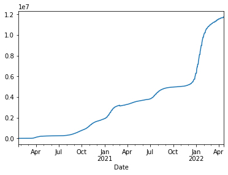

```python
df_es.set_index('Date')['Cases'].plot()
```

Nombraremos nuestro gráfico con el atributo *title* con `.plot(title=)`:

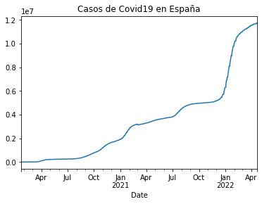

```python
df_es.set_index('Date')['Cases'].plot(title= "Casos de Covid19 en España")
```

Repetimos la operación con un nuevo país, Italia. Lo identificamos con *it*

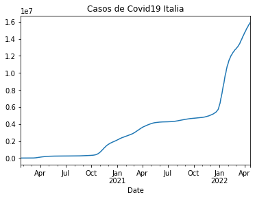

```python
url_it = 'https://api.covid19api.com/country/italy/status/confirmed/live'
df_it = pd.read_json(url_it)
df_it.set_index('Date')['Cases'].plot(title= "Casos de Covid19 Italia")
```

Ahora con Uruguay *ur*:

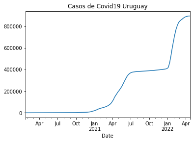

```python
url_ur = 'https://api.covid19api.com/country/uruguay/status/confirmed/live'
df_ur = pd.read_json(url_ur)
df_ur.set_index('Date')['Cases'].plot(title= "Casos de Covid19 Uruguay")
```

### Comparación

Las vistas creadas antes las vamos a guardar como objetos para poder agruparlos y compararlos.

```python
casos_es = df_es.set_index('Date')['Cases']
casos_it = df_it.set_index('Date')['Cases']
casos_ur = df_ur.set_index('Date')['Cases']
```

```python
casos_ur
```

```
Date
2020-01-22 00:00:00+00:00         0
2020-01-23 00:00:00+00:00         0
2020-01-24 00:00:00+00:00         0
2020-01-25 00:00:00+00:00         0
2020-01-26 00:00:00+00:00         0
                              ...
2022-04-18 00:00:00+00:00    895775
2022-04-19 00:00:00+00:00    895775
2022-04-20 00:00:00+00:00    895775
2022-04-21 00:00:00+00:00    895775
2022-04-22 00:00:00+00:00    895775
Name: Cases, Length: 822, dtype: int64
```

Vamos a concatenar los daots con la función `pd.concat`. Así los uniremos en el mismo dataframe. Es importante hacer la concatenación en el eje 1 `(axis=1)`

```python
pd.concat([casos_es,casos_it,casos_ur],axis=1)
```

| Date | Cases | Cases | Cases |
| --- | --- | --- | --- |
| 2020-01-22 00:00:00+00:00 | 0.0 | 0.0 | 0 |
| 2020-01-23 00:00:00+00:00 | 0.0 | 0.0 | 0 |
| 2020-01-24 00:00:00+00:00 | 0.0 | 0.0 | 0 |
| 2020-01-25 00:00:00+00:00 | 0.0 | 0.0 | 0 |
| 2020-01-26 00:00:00+00:00 | 0.0 | 0.0 | 0 |
| ... | ... | ... | ... |
| 2022-04-18 00:00:00+00:00 | 11662214.0 | 15730676.0 | 895775 |
| 2022-04-19 00:00:00+00:00 | 11736893.0 | 15758002.0 | 895775 |
| 2022-04-20 00:00:00+00:00 | 11736893.0 | 15858442.0 | 895775 |
| 2022-04-21 00:00:00+00:00 | 11736893.0 | 15934437.0 | 895775 |
| 2022-04-22 00:00:00+00:00 | NaN | NaN | 895775 |

822 rows × 3 columns

Para comparar los datos de los países vamos a crear un objeto llamado *vs*.

```python
vs = pd.concat([casos_es,casos_it,casos_ur],axis=1)
```

```python
vs
```

| Date | Cases | Cases | Cases |
| --- | --- | --- | --- |
| 2020-01-22 00:00:00+00:00 | 0.0 | 0.0 | 0 |
| 2020-01-23 00:00:00+00:00 | 0.0 | 0.0 | 0 |
| 2020-01-24 00:00:00+00:00 | 0.0 | 0.0 | 0 |
| 2020-01-25 00:00:00+00:00 | 0.0 | 0.0 | 0 |
| 2020-01-26 00:00:00+00:00 | 0.0 | 0.0 | 0 |
| ... | ... | ... | ... |
| 2022-04-18 00:00:00+00:00 | 11662214.0 | 15730676.0 | 895775 |
| 2022-04-19 00:00:00+00:00 | 11736893.0 | 15758002.0 | 895775 |
| 2022-04-20 00:00:00+00:00 | 11736893.0 | 15858442.0 | 895775 |
| 2022-04-21 00:00:00+00:00 | 11736893.0 | 15934437.0 | 895775 |
| 2022-04-22 00:00:00+00:00 | NaN | NaN | 895775 |

822 rows × 3 columns

Ahora crearemos el gráfico. Para ello vamos a nombrar las variables, los casos de cada país, con el nombre del país para la leyenda del gráfico:

```python
vs.columns = ['España', 'Italia', 'Uruguay']
```

```python
vs
```

| Date | España | Italia | Uruguay |
| --- | --- | --- | --- |
| 2020-01-22 00:00:00+00:00 | 0.0 | 0.0 | 0 |
| 2020-01-23 00:00:00+00:00 | 0.0 | 0.0 | 0 |
| 2020-01-24 00:00:00+00:00 | 0.0 | 0.0 | 0 |
| 2020-01-25 00:00:00+00:00 | 0.0 | 0.0 | 0 |
| 2020-01-26 00:00:00+00:00 | 0.0 | 0.0 | 0 |
| ... | ... | ... | ... |
| 2022-04-18 00:00:00+00:00 | 11662214.0 | 15730676.0 | 895775 |
| 2022-04-19 00:00:00+00:00 | 11736893.0 | 15758002.0 | 895775 |
| 2022-04-20 00:00:00+00:00 | 11736893.0 | 15858442.0 | 895775 |
| 2022-04-21 00:00:00+00:00 | 11736893.0 | 15934437.0 | 895775 |
| 2022-04-22 00:00:00+00:00 | NaN | NaN | 895775 |

822 rows × 3 columns

Como antes para visualizar el gráfico utilizaremos la función `.plot()`:

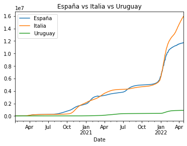

```python
vs.plot(title="España vs Italia vs Uruguay")
```

Vamos a elegir el tipo que gráfico que queremos, un gráfico de áreas, con el atributo `kind`

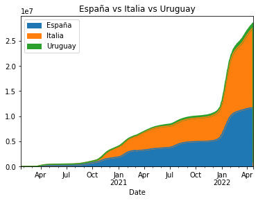

```python
vs.plot(title="España vs Italia vs Uruguay", kind='area')
```

### Guardar el gráfico

Vamos a guardar el dataframe *vs* como csv de la siguiente manera:

```python
vs.to_csv('esvsit.csv')
```

Para ver dónde lo hemos guardado:

```python
!ls
```

```
api-pandas-folium.ipynb  probando-con-r.ipynb		Shared_Resources
esvsit.csv		 python-api-covid-pandas.ipynb	Untitled.ipynb
```

### Guardar la imagen:

Importamos la librería matplotlib para guardarlo porque es aquella que permite visualizar los datos en Python.

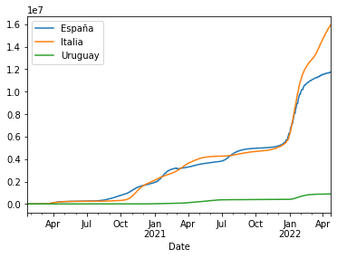

```python
import matplotlib.pyplot as plt
vs.plot()
plt.savefig('esvsit.png')
```